# Assignment 5

Lange Luntao

1/31/2021

*A new nonprofit organization led by Stanford students (some of whom participated in Future Bay Initiative projects) called unBox manages, as one of its projects, a resource navigation tool called Bay Area Community, which involves an extensive volunteer-based curation of location information for a variety of supportive services, such as school meals, WIC- or SNAP-eligible retailers, COVID-19 testing sites, and ballot drop-off locations.*

*Using techniques from this chapter, analyze the accessibility of various target populations to specific types of locations in BAC. The data can be downloaded from this Airtable (Navigate to … > Download CSV and read_csv() from your local machine); practice using the data manipulation techniques from this curriculum to filter the data to the locations of interest and prepare them for isochrone mapping. You are only required to pick one type of service of interest. You are welcome to pick a County of focus or analyze the entire Bay Area. Use 10 minute walking isochrones as your default accessibility scale, but you are welcome to make different choices for duration or mode depending on your question. Use 2017 LODES information about residents (RAC) or workers (WAC) at the block group or block level; if you would like to use other ACS characteristics in your analysis, you can add them as supplemental analyses. Clearly state all assumptions and include an interpretation of your results. Results can include counts of the % of a target population in a County that has what you define “good access” to the services, and/or an equity analysis comparing the full population to the “service-accessible” population along some group identity of interest. Include credits for BayAreaCommunity.org and unboxproject.org in your report.*

For this analysis, I chose to analyze the accessibility of school meal locations in one city and school district - San Francisco Unified School District. Using the same protocol as the textbook, I downloaded the unBox data and isolated only the school meal locations (which the [Google Doc](https://docs.google.com/document/d/1-1w2H6LItKZiSoxLqrgNILLR2qbw07rkeNUWondzTzI/edit) estimates is 90% accurate). I focused only on locations that were located in one of the San Francisco zip codes and were *also* run by San Francisco Unified School District. (The data indicated one school meal location that was run by Lodi USD, 90 miles away, which I assume was erroneous. It also included data on one location run by a school district just south of San Francisco. I removed both of these locations because policymakers in SFUSD will likely be interested only in SFUSD locations.)

Considering the fact that there are [fewer children in San Francisco than any of the 100 largest cities in America](https://www.nytimes.com/2017/01/21/us/san-francisco-children.html), I was curious to know if the location of school meal distribution centers was accessible in an equitable way for low-income workers in the city.

```r
sf_zipcodes <-
  c(
    "94102",
    "94103",
    "94104",
    "94105",
    "94107",
    "94108",
    "94109",
    "94110",
    "94111",
    "94112",
    "94114",
    "94115",
    "94116",
    "94117",
    "94118",
    "94121",
    "94122",
    "94123",
    "94124",
    "94127",
    "94129",
    "94130",
    "94131",
    "94132",
    "94133",
    "94134",
    "94158")

unboxlocations <-
  read_csv('~/Downloads/SFBI Database3.csv') %>%
  st_as_sf(coords = c("longitude", "latitude"),
           crs = 4326,
           na.fail=FALSE)
sf_meallocations <-
  filter(unboxlocations,zip %in% sf_zipcodes)%>%
  filter(taxonomy =="School Meals")%>%
  filter(Organization =="San Francisco Unified")


leaflet() %>%
  addProviderTiles(providers$CartoDB.Positron) %>%
  addCircleMarkers(
    data = sf_meallocations,
    radius = 1,
    label = ~Name
  )
```

[interactive chart not shown]

```r
walk_10min <- mb_isochrone(
  sf_meallocations,
  profile = "walking",
  time = 10
)

sf_meals_walk_10min <-
  sf_meallocations %>%
  st_set_geometry(NULL) %>%
  cbind(walk_10min$geometry) %>%
  st_as_sf()

leaflet() %>%
  addMapboxTiles(
    style_id = "streets-v11",
    username = "mapbox"
  ) %>%
  addPolygons(
    data = sf_meals_walk_10min,
    label = ~Name
  )
```

[interactive chart not shown]

I then intersected these isochrones with CBGs in order to compare the profile of the population that is within 10 minute walking distance of a school meal center to the population of San Francisco County as a whole. I decided to maintain this 10 minute walking metric because it aligns with [research on the maximum distance elementary school students and their families will normally walk to school](https://www.saferoutespartnership.org/blog/too-far-walk#:~:text=Most%20Safe%20Routes%20to%20School,acceptable%20distance%20for%20high%20schoolers.).

I first evaluated these trends using ACS 5-year community survey data to compare the overall populations in San Francisco and within a 10 minute walk of a school meal location.

```r
acs_vars_2018_5yr <-
  listCensusMetadata(
    name = "2018/acs/acs5",
    type = "variables"
  )

sfc_blockgroups_transformed <-
  block_groups("CA","075", cb = T, progress_bar = F) %>%
  st_transform(26910) %>%
  mutate(original_area = st_area(.))

sfc_bg_isochrone_intersect <-
  sfc_blockgroups_transformed %>%
  st_intersection(
    sf_meals_walk_10min %>%
      st_union() %>%
      st_transform(26910) %>%
      st_buffer(0)
  ) %>%
  mutate(
    leftover_area = st_area(.),
    perc_area = leftover_area / original_area
  )
sfc_bg_income <-
  getCensus(
    name = "acs/acs5",
    vintage = 2018,
    region = "block group:*",
    regionin = "state:06+county:075",
    vars = "group(B19001)"
  ) %>%
  mutate(cbg = paste0(state,county,tract,block_group)) %>%
  select(!c(GEO_ID,state,county,tract,block_group,NAME) & !ends_with(c("EA","MA","M"))) %>%
  pivot_longer(
    ends_with("E"),
    names_to = "variable",
    values_to = "estimate"
  ) %>%
  left_join(
    acs_vars_2018_5yr %>%
      select(name, label),
    by = c("variable" = "name")
  ) %>%
  select(-variable) %>%
  separate(
    label,
    into = c(NA,NA,"income"),
    sep = "!!"
  ) %>%
  filter(!is.na(income)) %>%
  mutate(
    income = case_when(
      income %in% c("Less than $10,000","$10,000 to $14,999","$15,000 to $19,999","$20,000 to $24,999") ~ "Less than $25,000",
      income %in% c("$25,000 to $29,999","$30,000 to $34,999","$35,000 to $39,999","$40,000 to $44,999","$45,000 to $49,999") ~ "$25,000 to $49,999",
      income %in% c("$50,000 to $59,999","$60,000 to $74,999") ~ "$50,000 to $74,999",
      TRUE ~ income
    )
  )
sfc_income <-
  sfc_bg_income %>%
  mutate(income = factor(income, levels = unique(sfc_bg_income$income))) %>%
  group_by(income) %>%
  summarize(estimate = sum(estimate)) %>%
  mutate(
    perc = estimate/sum(estimate),
    group = "Full Population"
  )

sfc_schoolmeals_income <-
  sfc_bg_income %>%
  mutate(income = factor(income, levels = unique(sfc_bg_income$income))) %>%
  left_join(
    sfc_bg_isochrone_intersect %>%
      select(cbg = GEOID, perc_area) %>%
      st_set_geometry(NULL)
  ) %>%
  filter(!is.na(perc_area)) %>%
  mutate(
    estimate = estimate * perc_area
  ) %>%
  group_by(income) %>%
  summarize(estimate = sum(estimate)) %>%
  mutate(
    perc = estimate/sum(estimate),
    group = "Population within 10 min. walk of a school lunch site"
  )
sum(sfc_schoolmeals_income$estimate)/
  sum(sfc_income$estimate)
```

```
## 0.3316547 [1]
```

I found that, in general, 33% of San Francisco residents are within a 10 minute walk of a school lunch center.

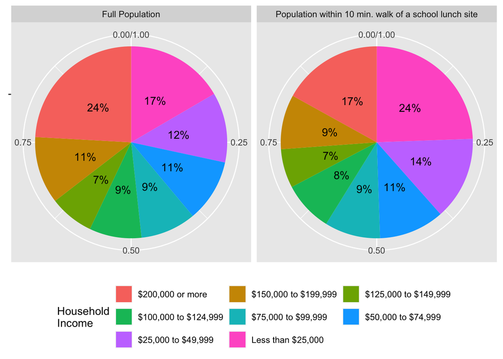

```r
rbind(sfc_income,sfc_schoolmeals_income) %>%
  ggplot(
    aes(
      x = "",
      y = perc,
      fill = reorder(income,desc(income))
    )
  ) +
  geom_bar(
    stat = "identity",
    position = position_fill()
  ) +
  geom_text(
    aes(label = paste0(round(perc*100),"%")),
    position = position_fill(vjust = 0.5)
  ) +
  coord_polar(theta = "y") +
  facet_wrap(~ group)  +
  theme(
    axis.title.x = element_blank(),
    axis.title.y = element_blank(),
    legend.position = 'bottom'
  ) +
  guides(
    fill = guide_legend(nrow=3, byrow=TRUE)
  ) +
  labs(
    fill = "Household\nIncome"
  )
```

The analysis of ACS data indicates that, if prioritizing for income equity, the locations are actually *more* accessible to low-income residents than we might expect. In general, roughly 29% of SF residents earn less than $49,999 per year – but considering the population within a 10 minute walk of a school lunch center, actually 38% come from households which earn less than $49,999 per year. I assume that education policymakers would be pleased to see these trends.

Lastly, I used LODES data to examine if the lowest-income workers (presumably whose families would benefit the most from subsidized meal programs) actually lived in the neighborhoods most served by these locations and services.

```r
ca_bgs <- block_groups("CA", cb = T, progress_bar = F)

ca_rac <- grab_lodes(
  state = "ca",
  year = 2017,
  lodes_type = "rac",
  job_type = "JT01",
  state_part = "main",
  agg_geo = "bg"
)
```

```
## Cached version of file found in /Users/langeluntao/Library/Caches/lehdr/ca_rac_S000_JT01_2017.csv.gz
## Reading now...
```

```r
sf_rac <-
  ca_rac %>%
  filter(h_bg %in% sfc_blockgroups_transformed$GEOID) %>%
  left_join(
    ca_bgs,
    by = c("h_bg" = "GEOID")
  ) %>%
  st_as_sf() %>%
  filter(C000 >= 5)

sf_jobs <-
  summarize(sf_rac,
            total_jobs = sum(C000),
            jobs_under_1250 = sum(CE01),
            jobs_1251_to_3333 = sum (CE02),
            jobs_over_3333 = sum(CE03)) %>%
  mutate(percentunder1250 = jobs_under_1250/total_jobs)


st_geometry(sf_jobs) <- NULL

kable(sf_jobs,
      caption = "Jobs w/ home addresses in San Francisco.",
      col.names = c('Total Jobs',
                    'Income <$1,250',
                    'Income Between $1,251 & $3,333',
                    'Income > $3,333',
                    'Percentage of jobs <$1,250'))
```

Jobs w/ home addresses in San Francisco.

| Total Jobs | Income <$1,250 | Income Between $1,251 & $3,333 | Income > $3,333 | Percentage of jobs <$1,250 |
| --- | --- | --- | --- | --- |
| 427423 | 46309 | 87841 | 293273 | 0.1083447 |

From looking at the 2017 LODES data, we can see that there are 427,423 jobs with home locations within the City and County of San Francisco, and of this, 46,309 (or 10.8%) of these jobs are paid less than $1,250 per month (less than $15,000 per year). Note: because the ACS data measures the household income of families, this is not a perfect comparison, but given that the LODES data separates jobs into three income brackets, the remainder of this analysis will focus only on the lowest-bracket jobs.

```r
sfc_schoolmeals_jobs <-
 sf_rac %>%
  transmute(h_bg = h_bg,
            total_jobs = C000,
            jobs_under_1250 = CE01,
            jobs_1251_to_3333 = CE02,
            jobs_over_3333 = CE03) %>%
  left_join(
    sfc_bg_isochrone_intersect %>%
      select(h_bg = GEOID, perc_area) %>%
      st_set_geometry(NULL)
  ) %>%
  transmute(
    jobs_bg_withinwalkofschool = total_jobs * perc_area,
    jobsunder1250_bg_withinwalkofschool = jobs_under_1250 * perc_area,
    jobs_1251_to_3333_bg_withinwalkofschool = jobs_1251_to_3333 * perc_area,
    jobs_over_3333_bg_withinwalkofschool = jobs_over_3333 * perc_area
  ) %>%
  summarize(totaljobs_withinwalkofschool = sum(jobs_bg_withinwalkofschool, na.rm = TRUE),
            jobsunder1250_withinwalkofschool = sum(jobsunder1250_bg_withinwalkofschool, na.rm = TRUE),
            jobs1251to3333_withinwalkofschool = sum(jobs_1251_to_3333_bg_withinwalkofschool, na.rm = TRUE),
            jobsover3333_withinwalkofschool = sum(jobs_over_3333_bg_withinwalkofschool, na.rm = TRUE)
  )%>%
  mutate(percentunder1250_withinwalkofschools = jobsunder1250_withinwalkofschool/totaljobs_withinwalkofschool)
st_geometry(sfc_schoolmeals_jobs) <- NULL

kable(sfc_schoolmeals_jobs,
      caption = "Jobs w/ Home Addresses within 10 min walk of schools.",
      col.names = c('Total Jobs',
                    'Income <$1,250',
                    'Income Between $1,251 & $3,333',
                    'Income > $3,333',
                    'Percentage of jobs <$1,250'))
```

Jobs w/ Home Addresses within 10 min walk of schools.

| Total Jobs | Income <$1,250 | Income Between $1,251 & $3,333 | Income > $3,333 | Percentage of jobs <$1,250 |
| --- | --- | --- | --- | --- |
| 141459.1 [1] | 17811.29 [1] | 34298.87 [1] | 89348.92 [1] | 0.1259113 [1] |

I found that, looking at all of the jobs that have a home address within a 10 minute walk of school sites in SF, 12.6% earn less than $1,250 per month – slightly higher than the average fo the city. This indicates that SFUSD may be meeting their goal of locating meal distribution sites in neighborhoods that are more accessible for lower-income residents.

As a next step, it would be valuable to consider which census blockgroups had the highest concentrations of low-income workers *without* access to a school meal location.

WORKS CITED - [BayAreaCommunity.org](https://bayareacommunity.org) - [UnBoxProject](https://unboxproject.org) - [Safe Routes to School Partnership - Acceptable Distances to Walk to School](https://www.saferoutespartnership.org/blog/too-far-walk#:~:text=Most%20Safe%20Routes%20to%20School,acceptable%20distance%20for%20high%20schoolers.) - [NYTimes - San Francisco Asks: Where Have All the Children Gone?](https://www.nytimes.com/2017/01/21/us/san-francisco-children.html) - U.S. Census Bureau. (2018). 2013-2017 American Community Survey 5-year Community Data.